# solubility_xgboost.Rmd

## Load the libraries

```r
library(tidyverse)
library(tidymodels)
library(ranger)
library(usemodels)
library(gridExtra)
library(vip)
theme_set(theme_classic())
```

## Load, split, and bootstrap sample the data.

I select the columns I will use as predictors here. I also make the train test split here and initialize the bootstrap sampling.

```r
df <- as_tibble(read.csv("data/delaney-processed.csv")) %>%
  select(
    compound = Compound.ID,
    mw = Molecular.Weight,
    h_bond_donors = Number.of.H.Bond.Donors,
    rings = Number.of.Rings,
    rotatable_bonds = Number.of.Rotatable.Bonds,
    psa = Polar.Surface.Area,
    solubility = measured.log.solubility.in.mols.per.litre
)

split <- initial_split(df)
train_data <- training(split)
test_data <- testing(split)
train_boot <- bootstraps(train_data, times = 10)
```

## Get boilerplate for an XGBoost regression.

I leverage usemodels to get the boilerplate code for an XGBoost model.

```r
usemodels::use_xgboost(solubility ~ mw + h_bond_donors + rings + rotatable_bonds + psa, data = train_data)
```

```
## xgboost_recipe <-
##   recipe(formula = solubility ~ mw + h_bond_donors + rings + rotatable_bonds +
##     psa, data = train_data) %>%
##   step_zv(all_predictors())
##
## xgboost_spec <-
##   boost_tree(trees = tune(), min_n = tune(), tree_depth = tune(), learn_rate = tune(),
##     loss_reduction = tune(), sample_size = tune()) %>%
##   set_mode("regression") %>%
##   set_engine("xgboost")
##
## xgboost_workflow <-
##   workflow() %>%
##   add_recipe(xgboost_recipe) %>%
##   add_model(xgboost_spec)
##
## set.seed(61186)
## xgboost_tune <-
##   tune_grid(xgboost_workflow, resamples = stop("add your rsample object"), grid = stop("add number of candidate points"))
```

## Assemble the model

Using the boilerplate suggestion above as a guide, I follow the steps below to prepare the XGBoost model for training.

### First, I make the recipe.

The recipe unites the data, formula, and preprocessing steps. Here, I use all the predictors. While all the predictors have non-zero variance, I still place the step_zv preprocessing step to remove zero-variance predictors as a best practice suggested by the boilerplate.

```r
xgboost_recipe <-
  recipe(formula = solubility ~ mw + h_bond_donors + rings + rotatable_bonds +
    psa, data = train_data) %>%
  step_zv(all_predictors())
```

### Second, I make the spec.

The specification sets the engine as XGBoost, the mode as regression, and specifies the hyperparameters needing tuning.

```r
xgboost_spec <-
  boost_tree(trees = tune(), min_n = tune(), tree_depth = tune(), learn_rate = tune(),
    loss_reduction = tune(), sample_size = tune()) %>%
  set_mode("regression") %>%
  set_engine("xgboost")
```

### Third, I make the workflow.

The workflow ties the spec and recipe together.

```r
xgboost_workflow <-
  workflow() %>%
  add_recipe(xgboost_recipe) %>%
  add_model(xgboost_spec)
```

### Fourth, I tune XGBoost

```r
set.seed(0)
doParallel::registerDoParallel()

xgboost_tune <-
  tune_grid(xgboost_workflow, resamples = train_boot, grid = 600)
```

## Evaluate the model

### First, I plot performance metrics during the model tuning.

Figure 1 reflects the RMSE and R^2 performance metrics during the tuning process.

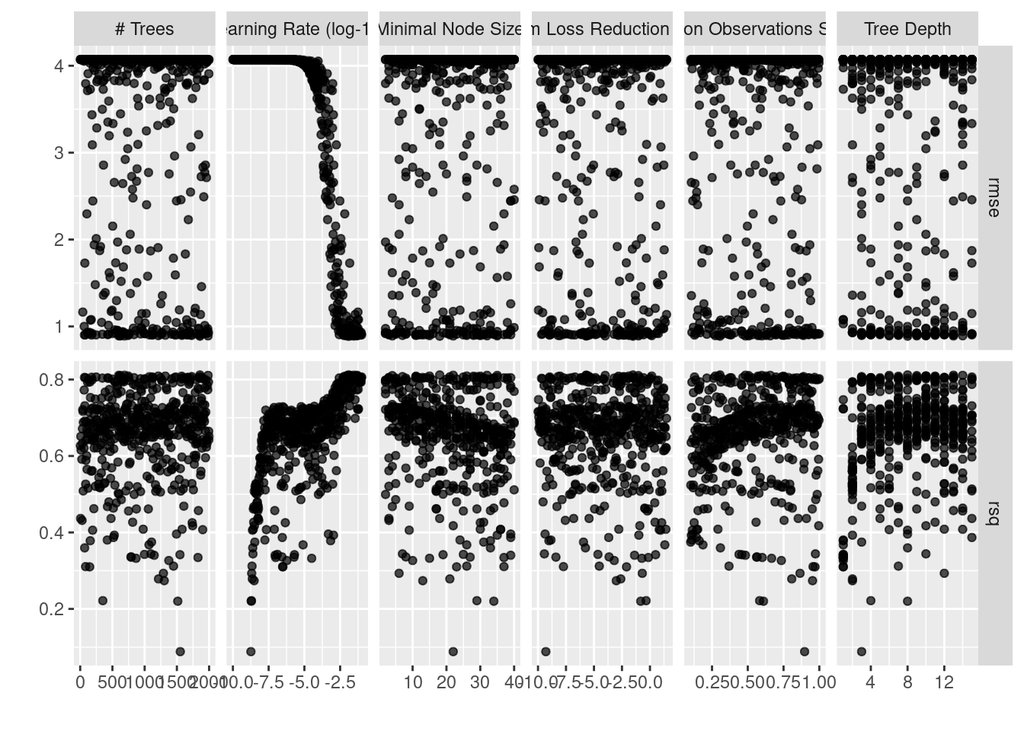

XGBoost Tuning Session

```r
autoplot(xgboost_tune) +
  theme_gray()
```

### Second, I finalize the workflow.

Workflow finalization selects the best performing hyperparameters based on the RMSE metric.

```r
final_xgb <- xgboost_workflow %>%
  finalize_workflow(select_best(xgboost_tune, metric = "rmse"))
```

## Third, I fit and collect predictions from the best-performing model.

In Figure 2, I plot the predictions with a trend line in the plot to see how well the model behaves on the test data.

```r
solubilty_fit <- last_fit(final_xgb, split)
collect_metrics(solubilty_fit)
```

```
## # A tibble: 2 x 4
##   .metric .estimator .estimate .config
##   <chr>   <chr>          <dbl> <chr>
## 1 rmse    standard       0.944 Preprocessor1_Model1
## 2 rsq     standard       0.807 Preprocessor1_Model1
```

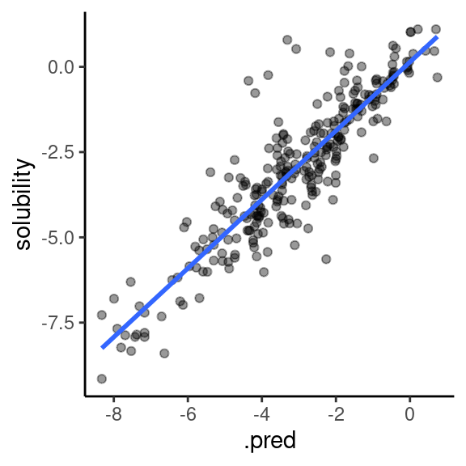

Actual vs predicted solubility

```r
collect_predictions(solubilty_fit) %>%
  ggplot(aes(.pred, solubility)) +
  geom_point(alpha = 0.4) +
  stat_smooth(method = "lm", se = FALSE)
```

### Finally, I check the variable importance.

In Figure 3 of variable importance, molecular weight is the most critical predictor of solubility for the XGBoost model.

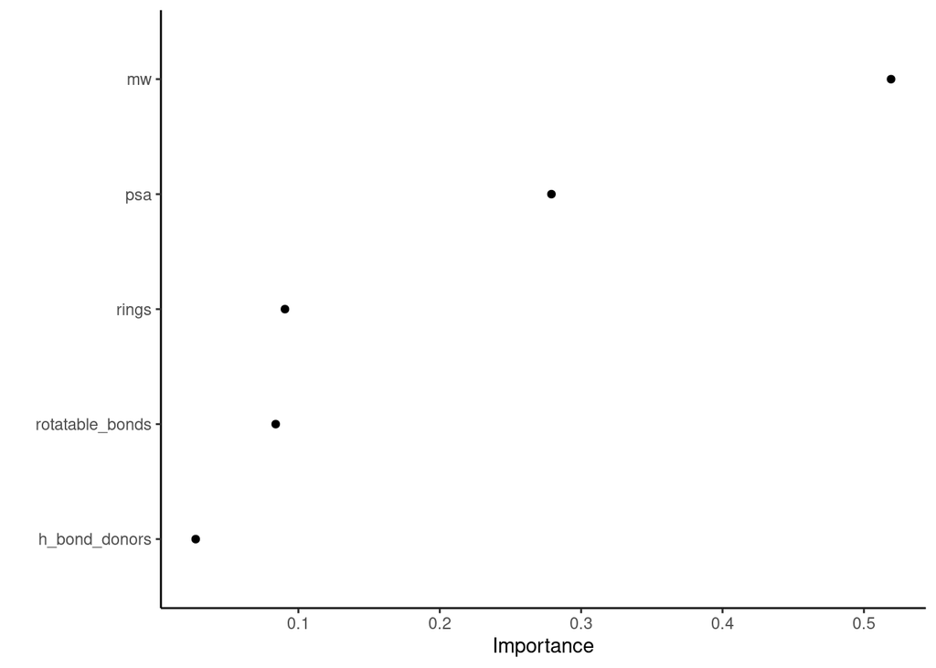

Variable importance

```r
final_xgb %>%
  fit(data = train_data) %>%
  pull_workflow_fit() %>%
  vip(geom = "point")
```

Figure 4 shows how molecular weight tends to increase as the number of features on a molecule increase.

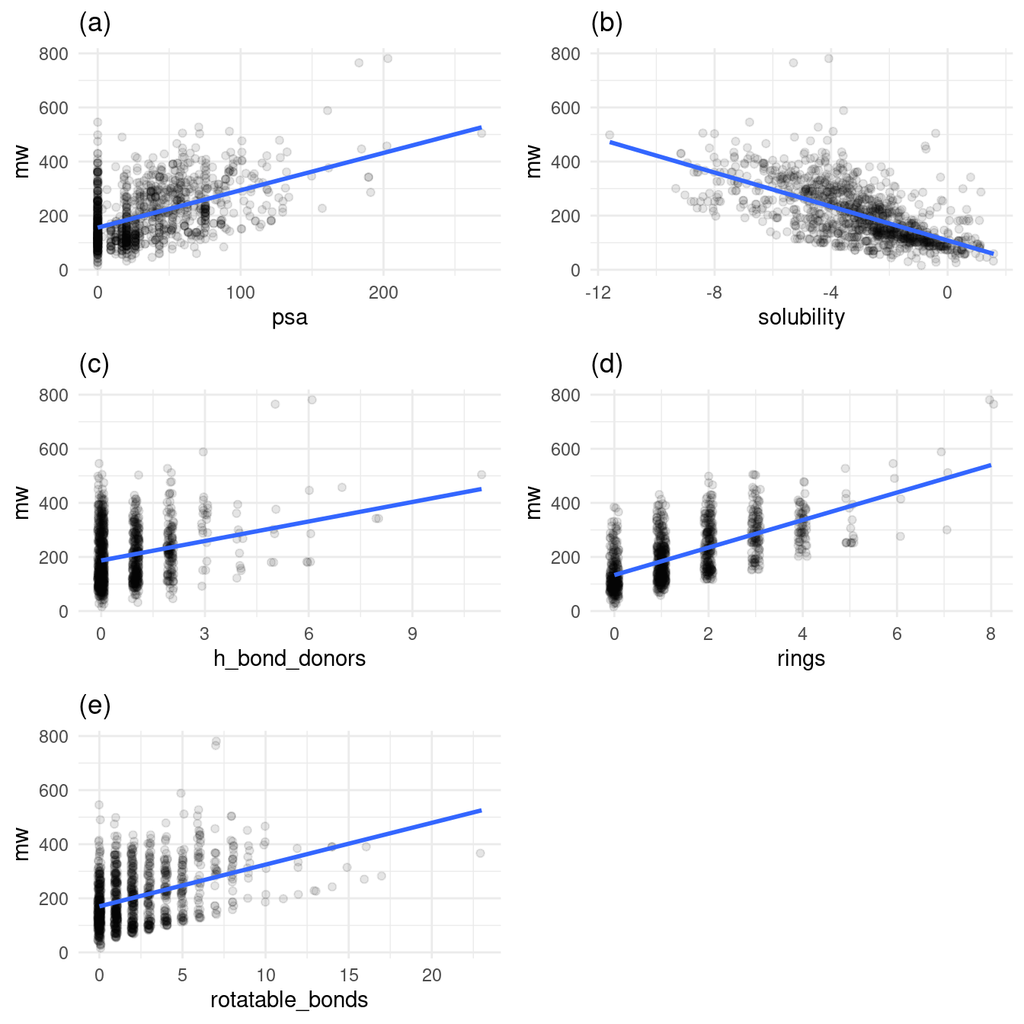

Relationship of molecular weight to other variables

```r
alpha = 0.1
p1 <- ggplot(df, aes(x = psa, y = mw)) +
  geom_jitter(alpha = alpha) +
  geom_smooth(method = "lm", se = FALSE) +
  labs(title = "(a)") +
  theme_minimal()

p2 <- ggplot(df, aes(x = solubility, y = mw)) +
  geom_jitter(alpha = alpha) +
  geom_smooth(method = "lm", se = FALSE) +
  labs(title = "(b)") +
  theme_minimal()

p3 <- ggplot(df, aes(x = h_bond_donors, y = mw)) +
  geom_jitter(alpha = alpha, width = 0.1) +
  geom_smooth(method = "lm", se = FALSE) +
  labs(title = "(c)") +
  theme_minimal()

p4 <- ggplot(df, aes(x = rings, y = mw)) +
  geom_jitter(alpha = alpha, width = 0.1) +
  geom_smooth(method = "lm", se = FALSE) +
  labs(title = "(d)") +
  theme_minimal()

p5 <- ggplot(df, aes(x = rotatable_bonds, y = mw)) +
  geom_jitter(alpha = alpha, width = 0.1) +
  geom_smooth(method = "lm", se = FALSE) +
  labs(title = "(e)") +
  theme_minimal()

grid.arrange(p1, p2, p3, p4, p5, nrow = 3)
```